实训项目指导书

# 实训项目简介

手势识别在设计智能高效的人机界面方面具有至关重要的作用。目前，手势识别已应用到手语识别、智能监控、虚拟现实等多个领域。手势识别的原理是利用各种传感器（例如摄像头、红外传感器等）对手部动作进行检测，并通过分类模型得到手势识别结果。在本项目中，你将学习构建一个用于实现手势识别的深度学习项目，该项目能够应用于识别手势数字（0~9），也就是说，模型的输入是RGB彩色图片，输出是对手势数字的分类结果。

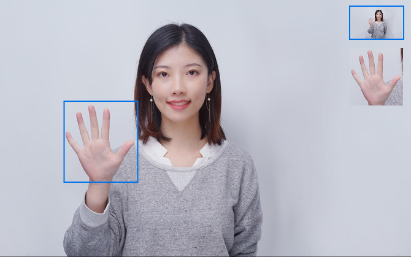

通过完成本实训项目，你将掌握以下技能：

- 使用Git进行代码管理；
- 设计和训练深度神经网络模型；
- 创建深度学习应用项目。

# 实训任务

基于手势图片数据集，设计并训练一个手势图片分类模型，分类结果为数字0~9。部分手势图片样例如下图所示：

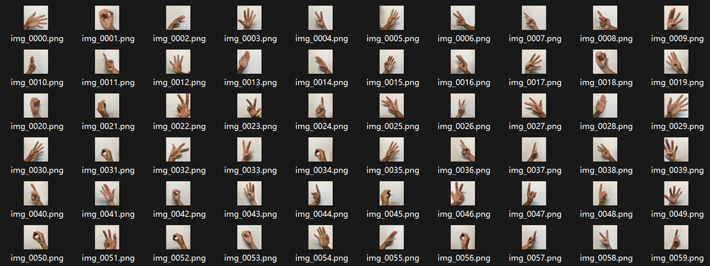

在项目初始代码的基础上进行模型开发，并测试模型的最终效果。

# 实训指引

## 初始代码及数据集下载

首先，下载项目的初始代码及数据集：https://gitee.com/sdtbu-nndl/nndl_project

```
git clone https://gitee.com/sdtbu-nndl/nndl_project.git
```

执行以上命令时，请保证Git已安装并配置好。

项目初始代码的目录结构如下：

```
nndl_project
	├─images
	│  ├─test
	│  ├─train
	│  ├─test.txt
	│  └─train.txt
	├─models
	├─dataset.py
	├─inference.py
	├─model.py
	├─test.py
	└─train.py
```

其中：

- `images`目录：包含本项目所需训练和测试数据集；
- `models`目录：用于保存训练好的模型；
- `dataset.py`：定义数据集加载类；
- `model.py`：定义模型；
- `train.py`：定义训练流程；
- `test.py`：定义测试流程；
- `inference.py`：利用训练好的模型进行推理。

## 数据集说明

`images`目录包含训练数据和测试数据集。样本为长宽均为64像素的彩色图片，样本标注信息记录在了`train.txt`和`test.txt`文件中：

```
./images/train/signs_3/img_0000.png 4
./images/train/signs_3/img_0001.png 1
./images/train/signs_3/img_0002.png 1
......
```

在以上示例中，`./images/train/signs_3/img_0000.png`为样本图片名称，`4`为标注信息，即图片所示的手势表示数字4。

## 完成项目代码

以下4个代码文件都是不完整的：

- `model.py`
- `train.py`
- `test.py`
- `inference.py`

你需要在`model.py`中完成模型定义，模型种类不限，你可以自由使用CNN、RNN、Transformer等模型或它们的组合完成本实训任务，之后在`train.py`、`test.py`中补全模型的训练和测试流程，最后，补全`inference.py`的代码，以便进行模型的应用。

需要补全代码的区域以`# START ------`注释行开始，以`# END ------`注释行结束，形如：

```
# START -------------------------------------------------------------------------

# END ---------------------------------------------------------------------------
```

请将你的代码填写在这两个注释行之间。

你可以使用PyCharm、Spider等Python IDE，或VSCode、Sublime Text、Vim等文本编辑器辅助完成本项目。

## 扩展

可以在上述内容基础上进一步扩展，如进行多种模型的性能比较、完成新模型的设计及测试、完成GUI界面开发、完成手机APP开发等。

# 实训成果提交要求

实训成果以小组为单位进行提交。提交内容包括：

- 完整代码提交至GitHub或Gitee代码仓库
- 实训项目报告（包括电子版和纸质版）

## 代码仓库

请保证代码仓库为`Public`（`开源`）状态，代码仓库地址请放在实训项目报告的醒目位置。

## 实训项目报告

### 格式及内容

实训项目报告格式参照模板，具体要求为：

- 一级标题：中文字体为黑体，西文字体为Times New Roman，四号
- 二级标题：中文字体为宋体，西文字体为Times New Roman，小四号、加粗
- 正文：中文字体为宋体，西文字体为Times New Roman，小四号，1.3倍行距
- 图表标题：中文字体为宋体，西文字体为Times New Roman，五号，1.3倍行距
- 段前、段后间距、正文缩进等根据实际需求设置即可

实训项目报告的内容需包括：

- **代码仓库地址**放在实训项目报告的醒目位置
- 实训项目的**完整代码**及对代码的**详细说明**
- 你认为必要的代码的**运行结果**

实训项目报告以**PDF格式**提交。如果报告是通过Word编辑的，还需要提交Word源文件（`.doc`或`.docx`格式）。如果报告是通过Latex编辑的，则无需提交Latex源码文件包。

### 常见问题

实训项目报告撰写过程中，请避免以下问题：

- 格式不规范，如中文字体为宋体，西文字体也为宋体
- 报告未包含代码仓库地址，或者代码仓库不可访问
- 报告内容全部是代码截图，缺乏必要的分析、说明

### 提交方式及截止时间

- 电子版实训项目报告发送到邮箱：dengfw@sdtbu.edu.cn
- 纸质版实训报告在实训结束前交到实训课的上课教室

实训报告提交截止时间：2024年7月12日24:00